# Developing Data Products Project

8 March 2018

## Introduction

This presentation is the part of [Developing Data Products](https://www.coursera.org/learn/data-products) project. The purpose of the presentation is to explain the working of the application created in the project. The links to the application, source code and documentation are given below:

- [Exploratory Analysis on 'mtcars' dataset](https://naqeebasif.shinyapps.io/DDPProject/)
- Documentation
- [Source Code](https://github.com/naqeebasif/DataScienceSpecializationCourseWork/tree/master/9_%20DevelopingDataProducts/Week4/Project3/DDPProject)

## Application Functionalities

The purpose of this application is to perform some of the exploratory analysis techniques on the [mtcars dataset](https://stat.ethz.ch/R-manual/R-devel/library/datasets/html/mtcars.html) which comes with 'R'. Following are the functionalities of the application:

1. Printing summary and structure of the data
2. If one feature is chosen then:
   - Plotting Histogram if the feature is numeric.
   - Plotting BarPlot if the feature is categorical.
3. If two features are chosen then plotting scatter plot as well as linear model.
4. Applying colours and the the facet grid by the chosen categorical feature.

## How the Application works

The application can be divided into two parts:

1. Summary Part
2. Graph Part

### 1. Summary Part

The checkbox is used to decide whether to display summary or structure of the data. Following R code is used to return either summary or structure of the data.

```r
if(input$checkSumm){h3("Summary")}
  else{h3("Structure")}
```

### 2. Graph Part

GGplot is used to display the graph. Basic ggplot object is created first and it is then modified according to the choices chosen by the user. For one of the choices the code similar to the following will be run:

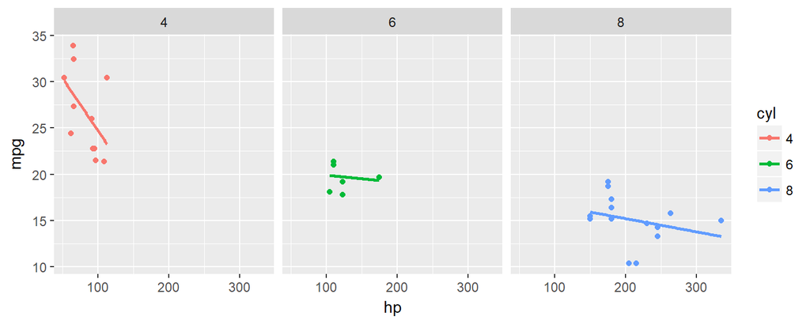

```r
ggplot(data=mtcars,aes(x=hp,y=mpg,colour=cyl)) +geom_point() +
  facet_grid(.~cyl)+geom_smooth(method="lm",se=F)
```